# Actividad - Proyecto práctico

> La actividad se desarrollará en grupos pre-definidos de 2-3 alumnos. Se debe indicar los nombres en orden alfabético (de apellidos). Recordad que esta actividad se corresponde con un 30% de la nota final de la asignatura. Se debe entregar entregar el trabajo en la presente notebook.

**Integrantes:**

- Silvia Martí Esteban
- Javier Martín Arranz
- Jose Mª Pérez Utrilla
- Jaime Peris Tchang

[figure not shown]

## **PARTE 1** - Instalación y requisitos previos

> Las prácticas han sido preparadas para poder realizarse en el entorno de trabajo de Google Colab. Sin embargo, esta plataforma presenta ciertas incompatibilidades a la hora de visualizar la renderización en gym. Por ello, para obtener estas visualizaciones, se deberá trasladar el entorno de trabajo a local. Por ello, el presente dosier presenta instrucciones para poder trabajar en ambos entornos. Siga los siguientes pasos para un correcto funcionamiento:
> 1. **LOCAL:** Preparar el enviroment, siguiendo las intrucciones detalladas en la sección *1.1.Preparar enviroment*.
> 2. **AMBOS:** Modificar las variables "mount" y "drive_mount" a la carpeta de trabajo en drive en el caso de estar en Colab, y ejecturar la celda *1.2.Localizar entorno de trabajo*.
> 3. **COLAB:** se deberá ejecutar las celdas correspondientes al montaje de la carpeta de trabajo en Drive. Esta corresponde a la sección *1.3.Montar carpeta de datos local*.
> 4. **AMBOS:** Instalar las librerías necesarias, siguiendo la sección *1.4.Instalar librerías necesarias*.

### 1.1. Preparar enviroment (solo local)

> Para preparar el entorno de trabajo en local, se han seguido los siguientes pasos:
> 1. En Windows, puede ser necesario instalar las C++ Build Tools. Para ello, siga los siguientes pasos: https://towardsdatascience.com/how-to-install-openai-gym-in-a-windows-environment-338969e24d30.
> 2. Instalar Anaconda
> 3. Siguiendo el código que se presenta comentado en la próxima celda: Crear un enviroment, cambiar la ruta de trabajo, e instalar librerías básicas.

```
conda create --name miar_rl python=3.8
conda activate miar_rl
cd "PATH_TO_FOLDER"
conda install git
pip install jupyter
```

1. Abrir la notebook con *jupyter-notebook*.

```
jupyter-notebook
```

### 1.2. Localizar entorno de trabajo: Google colab o local

```python
# ATENCIÓN!! Modificar ruta relativa a la práctica si es distinta (drive_root)
mount='/content/gdrive'
# drive_root = mount + "/My Drive/08_MIAR/actividades/proyecto practico"
drive_root = mount + "/My Drive/08_MIAR/pr/proyecto practico"

try:
  from google.colab import drive
  IN_COLAB=True
except:
  IN_COLAB=False
```

### 1.3. Montar carpeta de datos local (solo Colab)

```python
# Switch to the directory on the Google Drive that you want to use
import os
if IN_COLAB:
  print("We're running Colab")

  if IN_COLAB:
    # Mount the Google Drive at mount
    print("Colab: mounting Google drive on ", mount)

    drive.mount(mount)

    # Create drive_root if it doesn't exist
    create_drive_root = True
    if create_drive_root:
      print("\nColab: making sure ", drive_root, " exists.")
      os.makedirs(drive_root, exist_ok=True)

    # Change to the directory
    print("\nColab: Changing directory to ", drive_root)
    %cd $drive_root
# Verify we're in the correct working directory
%pwd
print("Archivos en el directorio: ")
print(os.listdir())
```

```
We're running Colab
Colab: mounting Google drive on  /content/gdrive

Colab: making sure  /content/gdrive/My Drive/08_MIAR/pr/proyecto practico  exists.

Colab: Changing directory to  /content/gdrive/My Drive/08_MIAR/pr/proyecto practico
/content/gdrive/My Drive/08_MIAR/pr/proyecto practico
Archivos en el directorio:
['hiperparametros.csv']
```

### 1.4. Instalar librerías necesarias

**Importante!** Cuidado con las versiones actualizadas de ciertas librerias, es recomendable utilizar las versiones deprecadas en ciertos casos para asegurar la compatibilidad entre módulos

```python
if IN_COLAB:
  %pip install gym==0.17.3
  %pip install numpy==1.23.5
  # %pip install numpy==1.24.3
  %pip install git+https://github.com/Kojoley/atari-py.git
  %pip install keras-rl2==1.0.5
  %pip install tensorflow==2.12.1
else:
  %pip install gym==0.17.3
  %pip install git+https://github.com/Kojoley/atari-py.git
  %pip install pyglet==1.5.0
  %pip install h5py==3.1.0
  %pip install Pillow==9.5.0
  %pip install keras-rl2==1.0.5
  %pip install Keras==2.2.4
  %pip install tensorflow==2.5.3
  %pip install torch==2.0.1
  %pip install agents==1.4.0
```

[output not shown]

[output not shown]

[output not shown]

[output cut: 51 more lines]

[output not shown]

```python
!pip install opencv-python==4.10.0.82
!pip install pydot==2.0.0
!pip install graphviz==0.20.3
```

[output not shown]

## **PARTE 2**. Enunciado

Consideraciones a tener en cuenta:

- El entorno sobre el que trabajaremos será *SpaceInvaders-v0* y el algoritmo que usaremos será *DQN*.
- Para nuestro ejercicio, el requisito mínimo será alcanzado cuando el agente consiga una **media de recompensa por encima de 20 puntos en modo test**. Por ello, esta media de la recompensa se calculará a partir del código de test en la última celda del notebook.

Este proyecto práctico consta de tres partes:

1. Implementar la red neuronal que se usará en la solución
2. Implementar las distintas piezas de la solución DQN
3. Justificar la respuesta en relación a los resultados obtenidos

**Rúbrica**: Se valorará la originalidad en la solución aportada, así como la capacidad de discutir los resultados de forma detallada. El requisito mínimo servirá para aprobar la actividad, bajo premisa de que la discusión del resultado sera apropiada.

IMPORTANTE:

- Si no se consigue una puntuación óptima, responder sobre la mejor puntuación obtenida.
- Para entrenamientos largos, recordad que podéis usar checkpoints de vuestros modelos para retomar los entrenamientos. En este caso, recordad cambiar los parámetros adecuadamente (sobre todo los relacionados con el proceso de exploración).
- Se deberá entregar unicamente el notebook y los pesos del mejor modelo en un fichero .zip, de forma organizada.
- Cada alumno deberá de subir la solución de forma individual.

## **PARTE 3**. Configuración Inicial y Pre-Procesado

#### 3.1 Importar librerías

```python
from __future__ import division

from PIL import Image
import numpy as np
import gym

# De Keras
from keras import Model
from keras.models import Sequential, load_model
from keras.layers import Dense, Activation, Flatten, Convolution2D, Permute, InputLayer, Conv2D, MaxPooling2D, GlobalAveragePooling2D, BatchNormalization, Lambda, UpSampling2D, Input, Resizing, Reshape
from keras.optimizers import Adam
import keras.backend as K

# De RL
from rl.agents.dqn import DQNAgent
from rl.policy import LinearAnnealedPolicy, BoltzmannQPolicy, EpsGreedyQPolicy
from rl.memory import SequentialMemory
from rl.core import Processor
from rl.callbacks import FileLogger, ModelIntervalCheckpoint

# Otras librerias
import matplotlib.pyplot as plt
import cv2
import tensorflow as tf
from tensorflow.keras.utils import plot_model
from tensorflow.keras.callbacks import Callback
import math
from collections import deque
import csv
from gym import wrappers
import io
import base64
from IPython.display import HTML
```

### 3.2 Pre-procesamiento personalizado del Entorno (propuesta)

Implementamos una clase `FrameAverageWrapper`, que extiende el entorno original de gym para aplicar un preprocesamiento específico a las observaciones visuales del agente. Esta clase:

- **Promedia múltiples frames consecutivos** para generar una imagen más estable, reduciendo el ruido visual entre frames (similar al frame stacking, pero suavizado).
- **Recorta la imagen** para eliminar zonas irrelevantes del entorno (por ejemplo, márgenes vacíos).
- **Modifica colores** específicos de píxeles:
  - Sustituye el número de **puntuación** por negro ([162,134,56] → [0,0,0]).
  - Cambia el color de las **balas** para resaltarlas ([142,142,142] → [255,255,255]).

Este preprocesamiento ayuda al agente a centrarse en elementos relevantes como enemigos y proyectiles, y a evitar distracciones del interfaz gráfico como marcadores o fondos.

```python
class FrameAverageWrapper(gym.Wrapper):
  def __init__(self, env, num_frames=4):
    super(FrameAverageWrapper, self).__init__(env)
    self.num_frames = num_frames
    self.frames = []

  def reset(self):
    obs = self._preprocess_observation(self.env.reset())
    self.frames = [obs] * self.num_frames
    return self._get_average_frame()

  def step(self, action):
    obs, reward, done, info = self.env.step(action)
    self.frames.append(self._preprocess_observation(obs))
    if len(self.frames) > self.num_frames:
      self.frames.pop(0)
    return self._get_average_frame(), reward, done, info

  def _get_average_frame(self):
    return np.mean(np.array(self.frames), axis=0).astype(np.uint8)

  def _crop_observation(self, obs):
    return obs[25:195]

  def _change_colors(self, obs, original_color, target_color):
    mask = np.all(obs == original_color, axis=-1)
    obs[mask] = target_color
    return obs

  def _remove_number_observation(self, obs):
    return self._change_colors(obs, [162, 134, 56], [0, 0, 0])

  def _change_bullet_color(self, obs):
    return self._change_colors(obs, [142, 142, 142], [255, 255, 255])

  def _preprocess_observation(self, obs):
    obs = self._crop_observation(obs)
    obs = self._remove_number_observation(obs)
    obs = self._change_bullet_color(obs)
    return obs
```

### 3.3 Configuración Base

```python
INPUT_SHAPE = (84, 84)
WINDOW_LENGTH = 1 # podemos probar con 4

env_name = 'SpaceInvaders-v0'
env = gym.make(env_name)

np.random.seed(123)
env.seed(123)
nb_actions = env.action_space.n
```

```python
env = FrameAverageWrapper(env)
```

```python
print(env.unwrapped.get_action_meanings())
```

```
['NOOP', 'FIRE', 'RIGHT', 'LEFT', 'RIGHTFIRE', 'LEFTFIRE']
```

#### 1. Setteamos los hiperparámetros

```python
# Hiperparametros de la red
LEARNING_RATE = 0.000005 # 0.000025

# Hiperparametros del agente
GAMMA = 0.95                  # Factor de descuento para las recompensas futuras. Controla cuánto peso se le da a las recompensas futuras
                              # en comparación con las inmediatas.
TARGET_MODEL_UPDATE = 1000    # Frecuencia con la que se actualiza el modelo objetivo
TRAIN_INTERVAL = 24            # determina cada cuántos pasos se entrena la red
DELTA_CLIP = 1.0              # Valor utilizado para recortar los errores TD (diferencia temporal) durante el entrenamiento para evitar
                              # fluctuaciones extremas.

WARM_UP = 1000                # steps de calentamiento antes de comenzar a medir en el training
```

```python
hyperparameters = {
  "INPUT_SHAPE": INPUT_SHAPE,
  "WINDOW_LENGTH": WINDOW_LENGTH,
  "LEARNING_RATE": LEARNING_RATE,
  "GAMMA": GAMMA,
  "TARGET_MODEL_UPDATE": TARGET_MODEL_UPDATE,
  "TRAIN_INTERVAL": TRAIN_INTERVAL,
  "DELTA_CLIP": DELTA_CLIP
}

# Nombre del archivo CSV
csv_file = 'hiperparametros.csv'

# Escribir los hiperparámetros en el archivo CSV
with open(csv_file, mode='w', newline='') as file:
  writer = csv.writer(file)
  writer.writerow(['Nombre', 'Valor'])
  for key, value in hyperparameters.items():
    writer.writerow([key, value])
```

#### 2. Creamos el procesador de observaciones y recompensas personalizado

Durante el desarrollo del proyecto se probaron dos versiones de la clase AtariProcessor, con el objetivo de optimizar la forma en que se procesan las observaciones y recompensas del entorno antes de ser entregadas al agente DQN. Aunque en la consigna se indicaba que debía utilizarse np.clip para limitar las recompensas, exploramos una versión alternativa más compleja que introducía una recompensa modelada manualmente.

**V1: Procesador con recompensas personalizadas**

De esta forma, este nuevo procesador personalizado proporciona un control más fino sobre la dinámica de entrenamiento que el que se nos daba de base, haciendo que el agente aprenda comportamientos más efectivos y específicos para el entorno.

```python
class AtariProcessor(Processor):

  def __init__(self):
    self.actual_lives = None
    self.last_lives = None

    self.actual_obs = None
    self.last_obs = None

  def process_observation(self, observation):
    assert observation.ndim == 3  # (height, width, channel)
    img = Image.fromarray(observation)
    img = img.resize(INPUT_SHAPE).convert('L')
    processed_observation = np.array(img)
    assert processed_observation.shape == INPUT_SHAPE

    self.actual_obs = observation
    return processed_observation.astype('uint8')

  def process_state_batch(self, batch):
    processed_batch = batch.astype('float32') / 255.
    return processed_batch

  def process_info(self, info):
    if 'ale.lives' in info:
      self.last_lives = self.actual_lives
      self.actual_lives = info['ale.lives']
    return info

  def process_reward(self, reward):
    recompensa_kill = 1 if reward > 0 else 0

    penalizacion_muerte = 0

    penalizacion_muerte = -4 if self.last_lives and self.actual_lives < self.last_lives else 0

    recompensa_total = recompensa_kill + penalizacion_muerte + self._process_move_rewad()

    return recompensa_total

  def _process_move_rewad(self):
    recompensa = 0

    if (self.last_obs is not None and np.allclose(self.actual_obs, self.last_obs)):
        recompensa = 0.1

    self.last_obs = self.actual_obs
    return recompensa
```

**V2: Procesador estándar**

Se define una clase `AtariProcessor`, que hereda de `rl.core.Processor`, para realizar un preprocesamiento básico de las observaciones y recompensas del entorno antes de entregarlas al agente DQN. Sus funciones clave son:

- `process_observation`: convierte cada imagen en escala de grises, la redimensiona a la forma esperada (84, 84) y la transforma a formato uint8, reduciendo así la complejidad visual que debe procesar la red.
- `process_state_batch`: normaliza los lotes de datos dividiendo entre 255, asegurando que las entradas se mantengan dentro de un rango consistente durante el entrenamiento.
- `process_reward`: aplica un recorte a la recompensa utilizando np.clip, limitando sus valores al rango [-1, 1] para evitar señales extremas que puedan desestabilizar el proceso de aprendizaje.

Este procesador proporciona una solución más simple y robusta que favorece la estabilidad del entrenamiento, especialmente en entornos complejos como Space Invaders, donde la recompensa original puede ser ruidosa o desbalanceada.

```python
class AtariProcessor(Processor):

  def process_observation(self, observation):
    assert observation.ndim == 3  # (height, width, channel)
    img = Image.fromarray(observation)
    img = img.resize(INPUT_SHAPE).convert('L')
    processed_observation = np.array(img)

    assert processed_observation.shape == INPUT_SHAPE
    return processed_observation.astype('uint8')

  def process_state_batch(self, batch):
    processed_batch = batch.astype('float32') / 255.
    return processed_batch

  def process_reward(self, reward):
    return np.clip(reward, -1., 1.)
```

```python
print("Numero de acciones disponibles: " + str(nb_actions))
```

```
Numero de acciones disponibles: 6
```

```python
print("Formato de las observaciones:")
env.observation_space
```

```
Formato de las observaciones:
```

```
Box(0, 255, (210, 160, 3), uint8)
```

[figure not shown]

```python
obs = env.reset()
plt.imshow(obs)
plt.show()
```

```python
def preprocess_observation(obs):
  # Convertir a escala de grises
  gray = cv2.cvtColor(obs, cv2.COLOR_RGB2GRAY)
  # Redimensionar la imagen a (84, 84)
  resized = cv2.resize(gray, (INPUT_SHAPE), interpolation=cv2.INTER_AREA)
  # Normalizar la imagen (opcional)
  normalized = resized / 255.0
  # Añadir una dimensión para el canal
  processed_obs = np.expand_dims(normalized, axis=-1)
  return processed_obs
```

[figure not shown]

```python
processed_obs = preprocess_observation(obs)
plt.imshow(processed_obs)
plt.show()
```

La utilización de un autoencoder variacional (VAE), se basa en que hemos visto que podría ser útil aprender una representación compacta y significativa de observaciones de alta dimensión, ya que en este caso nos permite extraer las características más relevantes de los datos sin supervisión, facilitando la reducción de dimensionalidad y eliminando redundancias.

La recolección de observaciones se realiza ejecutando secuencias de acciones aleatorias y prefijadas en el entorno, con el objetivo de capturar una muestra lo más diversa y representativa posible de los estados accesibles. Las observaciones obtenidas se someten a un proceso de preprocesamiento que incluye la normalización, la conversión a escala de grises y el redimensionado a una resolución estándar. Este preprocesamiento no solo reduce la complejidad y la redundancia de la información, sino que también homogeneiza el formato de entrada, facilitando el aprendizaje y la estabilidad del modelo.

Una vez preprocesadas, las imágenes se organizan en un dataset que se baraja y agrupa en lotes, optimizando el flujo de datos para el entrenamiento del VAE. La arquitectura implementada consta de un encoder convolucional, responsable de extraer características espaciales relevantes de las imágenes y proyectarlas en un espacio latente de baja dimensión, y de un decoder convolucional, encargado de reconstruir la imagen original a partir del vector latente. Este diseño fuerza al modelo a aprender representaciones útiles y compactas.

La función de pérdida utilizada combina la reconstrucción mediante binary crossentropy y la divergencia KL, regularizando el espacio latente para que siga una distribución normal estándar, lo que es esencial para dotar al modelo de capacidad generativa y robustez. Además, el uso del truco de reparametrización permite que el muestreo en el espacio latente sea diferenciable, haciendo posible el entrenamiento mediante retropropagación.

El entrenamiento del VAE se realiza de manera independiente y previa al entrenamiento del agente de RL, lo que garantiza la estabilidad y calidad de las representaciones latentes. Finalmente, la validación del modelo se lleva a cabo mediante la visualización de imágenes originales y sus reconstrucciones, comprobando así la capacidad del VAE para capturar la información esencial del entorno.

### 3.5 Arquitectura final de la red neuronal

```python
from keras.models import load_model
LATENT_DIM = 32

encoder_model = load_model('/encoder.h5') #importamos el encoder creado en el código anexo
```

```
WARNING:tensorflow:No training configuration found in the save file, so the model was *not* compiled. Compile it manually.
```

```python
encoder_model.summary()
```

```
Model: "encoder"
__________________________________________________________________________________________________
 Layer (type)                   Output Shape         Param #     Connected to
==================================================================================================
 input_5 (InputLayer)           [(None, 84, 84, 1)]  0           []

 conv2d_27 (Conv2D)             (None, 84, 84, 32)   320         ['input_5[0][0]']

 max_pooling2d_9 (MaxPooling2D)  (None, 42, 42, 32)  0           ['conv2d_27[0][0]']

 conv2d_28 (Conv2D)             (None, 42, 42, 64)   18496       ['max_pooling2d_9[0][0]']

 max_pooling2d_10 (MaxPooling2D  (None, 21, 21, 64)  0           ['conv2d_28[0][0]']
 )

 conv2d_29 (Conv2D)             (None, 21, 21, 128)  73856       ['max_pooling2d_10[0][0]']

 max_pooling2d_11 (MaxPooling2D  (None, 10, 10, 128)  0          ['conv2d_29[0][0]']
 )

 flatten_3 (Flatten)            (None, 12800)        0           ['max_pooling2d_11[0][0]']

 dense_12 (Dense)               (None, 128)          1638528     ['flatten_3[0][0]']

 dense_13 (Dense)               (None, 32)           4128        ['dense_12[0][0]']

 dense_14 (Dense)               (None, 32)           4128        ['dense_12[0][0]']

 lambda_3 (Lambda)              (None, 32)           0           ['dense_13[0][0]',
                                                                  'dense_14[0][0]']

==================================================================================================
Total params: 1,739,456
Trainable params: 1,739,456
Non-trainable params: 0
__________________________________________________________________________________________________
```

A continuación, se incorporan las **dos primeras capas del encoder preentrenado en modo congelado** (no entrenables), y posteriormente otras capas seleccionadas que sí se ajustarán durante el entrenamiento. Finalmente, se aplica una capa de GlobalAveragePooling2D para reducir la dimensionalidad y una capa Dense lineal como salida, que devuelve los valores Q correspondientes a cada acción posible.

```python
def create_dqn_model(input_shape, num_actions):
  model = Sequential()

  # Input layer: process input shape
  model.add(InputLayer(input_shape=(input_shape[0], input_shape[1], input_shape[2]))) #(84, 84, 1)

  # Permute layer to reorganize dimensions from (height, width, channels*4) to (channels*4, height, width)
  model.add(Permute((2, 3, 1)))

  for layer in encoder_model.layers[1:3]:
    layer.trainable = False
    model.add(layer)

  for layer in encoder_model.layers[3:7]:
    layer.trainable = True
    model.add(layer)

  model.add(GlobalAveragePooling2D())
  model.add(Dense(num_actions, activation='linear'))

  return model
```

```python
input_shape = (WINDOW_LENGTH,) + INPUT_SHAPE
num_actions = nb_actions # 6  Número de acciones posibles en Space Invaders

model = create_dqn_model(input_shape, num_actions)
```

```python
model.summary()
```

[output not shown]

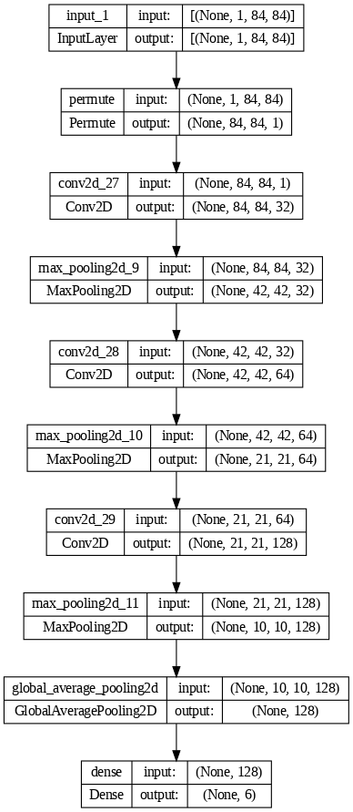

```python
plot_model(model,show_shapes=True, dpi=80)
```

### 3.6 Implementación de la solución DQN

```python
memory = SequentialMemory(limit=1000000, window_length=WINDOW_LENGTH)
```

```python
processor = AtariProcessor()
```

#### Seleccionamos la policy a emplear

```python
policy = EpsGreedyQPolicy(0.2) # 0.2
# policy = GreedyQPolicy()
```

```python
dqn = DQNAgent(
  model=model,
  nb_actions=num_actions,
  policy=policy,
  memory=memory,
  processor=processor,
  nb_steps_warmup = WARM_UP,
  gamma=GAMMA,
  target_model_update = TARGET_MODEL_UPDATE,
  train_interval = TRAIN_INTERVAL,
  delta_clip = DELTA_CLIP
)

optimizer = Adam(learning_rate = LEARNING_RATE)
dqn.compile(optimizer=optimizer, metrics=['mae'])
```

#### Guardamos sus pesos y métricas

Creamos las clases de guardado de pesos: [dqn_best_wieghts, dqn_last_weights]

Y de sus métricas de entrenamiento: [training_metrics]

```python
class SaveBestWeights(Callback):
  def __init__(self, filepath, interval=20, overwrite=True):
    super(SaveBestWeights, self).__init__()
    self.filepath = filepath
    self.interval = interval
    self.best_reward = -float('inf')
    self.overwrite = overwrite

  def on_episode_end(self, episode, logs={}):
    if episode % self.interval == 0:
      current_reward = logs.get('episode_reward')
      if current_reward > self.best_reward:
        self.best_reward = current_reward
        #self.model.save_weights(self.filepath)
        #print(f'Pesos guardados en {self.filepath} recompensa: {self.best_reward}')
        if self.overwrite or not os.path.exists(self.filepath):
          self.model.save_weights(self.filepath, overwrite=True)
          print(f'Pesos guardados en {self.filepath} recompensa: {self.best_reward}')
        else:
          print(f'Warning: No se sobrescribió {self.filepath}, ya existe.')
```

```python
filepath = 'dqn_best_weights.h5'
save_best_weights = SaveBestWeights(filepath=filepath, interval=1, overwrite=True)
```

```python
class SaveLastWeights(Callback):
  def __init__(self, filepath, interval=10):
    super(SaveLastWeights, self).__init__()
    self.filepath = filepath
    self.interval = interval

  def on_episode_end(self, episode, logs={}):
    if episode % self.interval == 0:
      self.model.save_weights(self.filepath, overwrite=True)
      print(f'Pesos guardados en {self.filepath} al final del episodio {episode}')
```

```python
filepathlw = 'dqn_last_weights.h5'

save_last_weights = SaveLastWeights(filepath=filepathlw, interval=10)
```

```python
class MetricsLogger(Callback):
  def __init__(self, filepath):
    self.filepath = filepath
    with open(self.filepath, mode='w') as file:
      writer = csv.writer(file)
      writer.writerow(['episode', 'reward', 'steps'])

  def on_episode_end(self, episode, logs={}):
    reward = logs.get('episode_reward')
    steps = logs.get('nb_episode_steps')

    with open(self.filepath, mode='a') as file:
      writer = csv.writer(file)
      writer.writerow([episode, reward, steps])
```

```python
metrics_logger = MetricsLogger('training_metrics.csv')
```

#### Añadimos el EarlyStopping por recompensas alcanzadas (si se llega al reward threshold)

```python
class EarlyStoppingByReward(Callback):
  def __init__(self, reward_threshold, patience):
    super(EarlyStoppingByReward, self).__init__()
    self.reward_threshold = reward_threshold
    self.patience = patience
    self.recent_rewards = deque(maxlen=patience)

  def on_episode_end(self, episode, logs={}):
    current_reward = logs.get('episode_reward')
    self.recent_rewards.append(current_reward)

    if len(self.recent_rewards) == self.patience and all(r > self.reward_threshold for r in self.recent_rewards):
      self.model.stop_training = True
      print(f'Detener el entrenamiento al exceder la recompensa media {self.reward_threshold} en {self.patience} episodios')
```

```python
early_stopping = EarlyStoppingByReward(reward_threshold=20, patience=10)
```

```python
log_filename = 'dqn_{}_log.json'.format(env_name)
```

```python
if os.path.exists(filepathlw):
  print(f'Cargamos los pesos de {filepathlw}')
  dqn.load_weights(filepathlw)
else:
  print('No hay un fichero de pesos, entrenando la red desde cero')
```

```
Cargamos los pesos de dqn_last_weights.h5
```

## **PARTE 4**. Entrenamiento de la red

Se entrena el agente DQN durante 500.000 pasos utilizando el entorno SpaceInvaders-v0. El entrenamiento se realiza sin visualización y con registro periódico de métricas cada 10.000 pasos. Además, se emplean las diversas funciones de callback definidas previamente que permiten controlar y registrar el proceso de entrenamiento:

```python
#dqn.fit(env, nb_steps=1000000, visualize=False, verbose=2, callbacks=[save_best_weights, early_stopping])
train_scores = dqn.fit(
  env,
  nb_steps=500000,
  visualize=False,
  verbose=2,
  log_interval=10000,
  callbacks=[
    save_best_weights,
    save_last_weights,
    metrics_logger,
    early_stopping,
    FileLogger(
      log_filename,
      interval=100)
      ]
  )
```

```
Training for 500000 steps ...
```

```
Pesos guardados en dqn_best_weights.h5 recompensa: 2.9999999999999996
Pesos guardados en dqn_last_weights.h5 al final del episodio 0
    709/500000: episode: 1, duration: 8.535s, episode steps: 709, steps per second:  83, episode reward:  3.000, mean reward:  0.004 [-4.000,  1.000], mean action: 2.343 [0.000, 5.000],  loss: --, mae: --, mean_q: --
```

```
   1264/500000: episode: 2, duration: 9.865s, episode steps: 555, steps per second:  56, episode reward: -0.500, mean reward: -0.001 [-4.000,  1.000], mean action: 2.980 [0.000, 5.000],  loss: 0.003972, mae: 0.504849, mean_q: 0.628813
   1884/500000: episode: 3, duration: 13.475s, episode steps: 620, steps per second:  46, episode reward: -1.400, mean reward: -0.002 [-4.000,  1.000], mean action: 2.763 [0.000, 5.000],  loss: 0.008812, mae: 0.492970, mean_q: 0.614092
   2669/500000: episode: 4, duration: 18.284s, episode steps: 785, steps per second:  43, episode reward:  1.700, mean reward:  0.002 [-4.000,  1.000], mean action: 2.403 [0.000, 5.000],  loss: 0.024581, mae: 0.490068, mean_q: 0.608013
Pesos guardados en dqn_best_weights.h5 recompensa: 4.3000000000000025
   3438/500000: episode: 5, duration: 16.508s, episode steps: 769, steps per second:  47, episode reward:  4.300, mean reward:  0.006 [-4.000,  1.000], mean action: 1.782 [0.000, 5.000],  loss: 0.025920, mae: 0.483808, mean_q: 0.602120
Pesos guardados en dqn_best_weights.h5 recompensa: 7.0999999999999925
   4252/500000: episode: 6, duration: 17.764s, episode steps: 814, steps per second:  46, episode reward:  7.100, mean reward:  0.009 [-4.000,  1.000], mean action: 1.547 [0.000, 5.000],  loss: 0.013019, mae: 0.470387, mean_q: 0.590281
   5052/500000: episode: 7, duration: 17.640s, episode steps: 800, steps per second:  45, episode reward:  2.000, mean reward:  0.003 [-4.000,  1.000], mean action: 2.422 [0.000, 5.000],  loss: 0.018665, mae: 0.468258, mean_q: 0.585880
   5722/500000: episode: 8, duration: 14.348s, episode steps: 670, steps per second:  47, episode reward: -1.900, mean reward: -0.003 [-4.000,  1.000], mean action: 1.860 [0.000, 5.000],  loss: 0.022381, mae: 0.468939, mean_q: 0.585458
   6466/500000: episode: 9, duration: 15.916s, episode steps: 744, steps per second:  47, episode reward:  2.500, mean reward:  0.003 [-4.000,  1.000], mean action: 1.444 [0.000, 5.000],  loss: 0.011906, mae: 0.467937, mean_q: 0.586558
Pesos guardados en dqn_best_weights.h5 recompensa: 11.199999999999989
   7520/500000: episode: 10, duration: 23.998s, episode steps: 1054, steps per second:  44, episode reward: 11.200, mean reward:  0.011 [-4.000,  1.000], mean action: 1.792 [0.000, 5.000],  loss: 0.036838, mae: 0.463303, mean_q: 0.575849
Pesos guardados en dqn_last_weights.h5 al final del episodio 10
   8233/500000: episode: 11, duration: 15.969s, episode steps: 713, steps per second:  45, episode reward:  2.200, mean reward:  0.003 [-4.000,  1.000], mean action: 1.410 [0.000, 5.000],  loss: 0.034460, mae: 0.453919, mean_q: 0.566180
   9578/500000: episode: 12, duration: 29.044s, episode steps: 1345, steps per second:  46, episode reward:  5.400, mean reward:  0.004 [-4.000,  1.000], mean action: 1.938 [0.000, 5.000],  loss: 0.014218, mae: 0.449712, mean_q: 0.565051
  10888/500000: episode: 13, duration: 27.808s, episode steps: 1310, steps per second:  47, episode reward:  6.700, mean reward:  0.005 [-4.000,  1.000], mean action: 2.002 [0.000, 5.000],  loss: 0.018206, mae: 0.442015, mean_q: 0.556498
  11613/500000: episode: 14, duration: 15.459s, episode steps: 725, steps per second:  47, episode reward:  7.900, mean reward:  0.011 [-4.000,  1.000], mean action: 2.309 [0.000, 5.000],  loss: 0.019773, mae: 0.436121, mean_q: 0.548359
  12557/500000: episode: 15, duration: 21.442s, episode steps: 944, steps per second:  44, episode reward:  4.800, mean reward:  0.005 [-4.000,  1.000], mean action: 2.200 [0.000, 5.000],  loss: 0.011436, mae: 0.432222, mean_q: 0.545178
  13275/500000: episode: 16, duration: 17.087s, episode steps: 718, steps per second:  42, episode reward:  1.700, mean reward:  0.002 [-4.000,  1.000], mean action: 1.639 [0.000, 5.000],  loss: 0.006502, mae: 0.431521, mean_q: 0.544055
  14009/500000: episode: 17, duration: 15.643s, episode steps: 734, steps per second:  47, episode reward:  7.800, mean reward:  0.011 [-4.000,  1.000], mean action: 1.771 [0.000, 5.000],  loss: 0.013358, mae: 0.428171, mean_q: 0.540262
  14647/500000: episode: 18, duration: 14.051s, episode steps: 638, steps per second:  45, episode reward:  0.800, mean reward:  0.001 [-4.000,  1.000], mean action: 2.251 [0.000, 5.000],  loss: 0.018656, mae: 0.433923, mean_q: 0.544336
  15053/500000: episode: 19, duration: 9.342s, episode steps: 406, steps per second:  43, episode reward:  0.000, mean reward:  0.000 [-4.000,  1.000], mean action: 1.924 [0.000, 5.000],  loss: 0.020059, mae: 0.430827, mean_q: 0.540578
  15920/500000: episode: 20, duration: 18.060s, episode steps: 867, steps per second:  48, episode reward: 11.100, mean reward:  0.013 [-4.000,  1.000], mean action: 1.925 [0.000, 5.000],  loss: 0.025858, mae: 0.431761, mean_q: 0.540431
Pesos guardados en dqn_last_weights.h5 al final del episodio 20
  16729/500000: episode: 21, duration: 17.950s, episode steps: 809, steps per second:  45, episode reward:  4.500, mean reward:  0.006 [-4.000,  1.000], mean action: 1.790 [0.000, 5.000],  loss: 0.012064, mae: 0.422034, mean_q: 0.533867
  17153/500000: episode: 22, duration: 9.406s, episode steps: 424, steps per second:  45, episode reward:  0.500, mean reward:  0.001 [-4.000,  1.000], mean action: 1.946 [0.000, 5.000],  loss: 0.009376, mae: 0.424273, mean_q: 0.535577
```

[output cut: 317 more lines]

## **PARTE 5**. Test de Resultados del Modelo

### 5.1 Configuración y logger de las acciones

```python
from gym import wrappers
import io
import base64
from IPython.display import HTML
```

```python
class Logger_test(Callback):
  def __init__(self):
      self.episode_actions = []

  def on_episode_begin(self, episode, logs={}):
      self.current_actions = []

  def on_action_end(self, action, logs={}):
      self.current_actions.append(action)

  def on_episode_end(self, episode, logs={}):
      self.episode_actions.append(self.current_actions)
      print(f"Acciones del episodio {episode}: {self.current_actions}")

logger = Logger_test()
```

```python
env.close()
```

```python
env = wrappers.Monitor(env, "./Videos", force=True) # Para guardar los videos de las partidas
                                                    # necesario instalar ffmpeg
```

### 5.2 Fase de Test para calcular la Recompensa Media

Cargamos los ultimos pesos obtenidos en el entrenamiento y procedemos a testearlos en un set de N episodios:

```python
# Testing part to calculate the mean reward
weights_filename = 'dqn_last_weights.h5'

# Cargamos los pesos en la DQN y calculamos las test scores obtenidas en N episodios
dqn.load_weights(weights_filename)
test_scores = dqn.test(env, nb_episodes=10, visualize=False, callbacks=[logger])
```

```
Testing for 10 episodes ...
```

```
Acciones del episodio 0: [4, 4, 4, 4, 4, 4, 4, 4, 4, 4, 4, 4, 4, 4, 4, 4, 4, 4, 4, 4, 4, 4, 4, 4, 4, 4, 4, 4, 4, 4, 4, 4, 4, 4, 4, 4, 4, 4, 4, 4, 4, 4, 4, 4, 4, 4, 4, 4, 4, 4, 4, 4, 4, 4, 4, 4, 4, 4, 4, 4, 4, 4, 4, 4, 4, 4, 4, 4, 4, 4, 4, 4, 4, 4, 4, 4, 4, 4, 4, 4, 4, 4, 4, 4, 4, 4, 4, 4, 4, 4, 4, 4…
Episode 1: reward: 21.000, steps: 852
Acciones del episodio 1: [4, 4, 4, 4, 4, 4, 4, 4, 4, 4, 4, 4, 4, 4, 4, 4, 4, 4, 4, 4, 4, 4, 4, 4, 4, 4, 4, 4, 4, 4, 4, 4, 4, 4, 4, 4, 4, 4, 4, 4, 4, 4, 4, 4, 4, 4, 4, 4, 4, 4, 4, 4, 4, 4, 4, 4, 4, 4, 4, 4, 4, 4, 4, 4, 4, 4, 4, 4, 4, 4, 4, 4, 4, 4, 4, 4, 4, 4, 4, 4, 4, 4, 4, 4, 4, 4, 4, 4, 4, 4, 4, 4…
Episode 2: reward: 26.000, steps: 921
Acciones del episodio 2: [4, 4, 4, 4, 4, 4, 4, 4, 4, 4, 4, 4, 4, 4, 4, 4, 4, 4, 4, 4, 4, 4, 4, 4, 4, 4, 4, 4, 4, 4, 4, 4, 4, 4, 4, 4, 4, 4, 4, 4, 4, 4, 4, 4, 4, 4, 4, 4, 4, 4, 4, 4, 4, 4, 4, 4, 4, 4, 4, 4, 4, 4, 4, 4, 4, 4, 4, 4, 4, 4, 4, 4, 4, 4, 4, 4, 4, 4, 4, 4, 4, 4, 4, 4, 4, 4, 4, 4, 4, 4, 4, 4…
Episode 3: reward: 23.000, steps: 917
Acciones del episodio 3: [4, 4, 4, 4, 4, 4, 4, 4, 4, 4, 4, 4, 4, 4, 4, 4, 4, 4, 4, 4, 4, 4, 4, 4, 4, 4, 4, 4, 4, 4, 4, 4, 4, 4, 4, 4, 4, 4, 4, 4, 4, 4, 4, 4, 4, 4, 4, 4, 4, 4, 4, 4, 4, 4, 4, 4, 4, 4, 4, 4, 4, 4, 4, 4, 4, 4, 4, 4, 4, 4, 4, 4, 4, 4, 4, 4, 4, 4, 4, 4, 4, 4, 4, 4, 4, 4, 4, 4, 4, 4, 4, 4…
Episode 4: reward: 22.000, steps: 873
Acciones del episodio 4: [4, 4, 4, 4, 4, 4, 4, 4, 4, 4, 4, 4, 4, 4, 4, 4, 4, 4, 4, 4, 4, 4, 4, 4, 4, 4, 4, 4, 4, 4, 4, 4, 4, 4, 4, 4, 4, 4, 4, 4, 4, 4, 4, 4, 4, 4, 4, 4, 4, 4, 4, 4, 4, 4, 4, 4, 4, 4, 4, 4, 4, 4, 4, 4, 4, 4, 4, 4, 4, 4, 4, 4, 4, 4, 4, 4, 4, 4, 4, 4, 4, 4, 4, 4, 4, 4, 4, 4, 4, 4, 4, 4…
Episode 5: reward: 19.000, steps: 691
Acciones del episodio 5: [4, 4, 4, 4, 4, 4, 4, 4, 4, 4, 4, 4, 4, 4, 4, 4, 4, 4, 4, 4, 4, 4, 4, 4, 4, 4, 4, 4, 4, 4, 4, 4, 4, 4, 4, 4, 4, 4, 4, 4, 4, 4, 4, 4, 4, 4, 4, 4, 4, 4, 4, 4, 4, 4, 4, 4, 4, 4, 4, 4, 4, 4, 4, 4, 4, 4, 4, 4, 4, 4, 4, 4, 4, 4, 4, 4, 4, 4, 4, 4, 4, 4, 4, 4, 4, 4, 4, 4, 4, 4, 4, 4…
Episode 6: reward: 23.000, steps: 881
Acciones del episodio 6: [4, 4, 4, 4, 4, 4, 4, 4, 4, 4, 4, 4, 4, 4, 4, 4, 4, 4, 4, 4, 4, 4, 4, 4, 4, 4, 4, 4, 4, 4, 4, 4, 4, 4, 4, 4, 4, 4, 4, 4, 4, 4, 4, 4, 4, 4, 4, 4, 4, 4, 4, 4, 4, 4, 4, 4, 4, 4, 4, 4, 4, 4, 4, 4, 4, 4, 4, 4, 4, 4, 4, 4, 4, 4, 4, 4, 4, 4, 4, 4, 4, 4, 4, 4, 4, 4, 4, 4, 4, 4, 4, 4…
Episode 7: reward: 21.000, steps: 868
Acciones del episodio 7: [4, 4, 4, 4, 4, 4, 4, 4, 4, 4, 4, 4, 4, 4, 4, 4, 4, 4, 4, 4, 4, 4, 4, 4, 4, 4, 4, 4, 4, 4, 4, 4, 4, 4, 4, 4, 4, 4, 4, 4, 4, 4, 4, 4, 4, 4, 4, 4, 4, 4, 4, 4, 4, 4, 4, 4, 4, 4, 4, 4, 4, 4, 4, 4, 4, 4, 4, 4, 4, 4, 4, 4, 4, 4, 4, 4, 4, 4, 4, 4, 4, 4, 4, 4, 4, 4, 4, 4, 4, 4, 4, 4…
Episode 8: reward: 26.000, steps: 914
Acciones del episodio 8: [4, 4, 4, 4, 4, 4, 4, 4, 4, 4, 4, 4, 4, 4, 4, 4, 4, 4, 4, 4, 4, 4, 4, 4, 4, 4, 4, 4, 4, 4, 4, 4, 4, 4, 4, 4, 4, 4, 4, 4, 4, 4, 4, 4, 4, 4, 4, 4, 4, 4, 4, 4, 4, 4, 4, 4, 4, 4, 4, 4, 4, 4, 4, 4, 4, 4, 4, 4, 4, 4, 4, 4, 4, 4, 4, 4, 4, 4, 4, 4, 4, 4, 4, 4, 4, 4, 4, 4, 4, 4, 4, 4…
Episode 9: reward: 18.000, steps: 706
Acciones del episodio 9: [4, 4, 4, 4, 4, 4, 4, 4, 4, 4, 4, 4, 4, 4, 4, 4, 4, 4, 4, 4, 4, 4, 4, 4, 4, 4, 4, 4, 4, 4, 4, 4, 4, 4, 4, 4, 4, 4, 4, 4, 4, 4, 4, 4, 4, 4, 4, 4, 4, 4, 4, 4, 4, 4, 4, 4, 4, 4, 4, 4, 4, 4, 4, 4, 4, 4, 4, 4, 4, 4, 4, 4, 4, 4, 4, 4, 4, 4, 4, 4, 4, 4, 4, 4, 4, 4, 4, 4, 4, 4, 4, 4…
Episode 10: reward: 18.000, steps: 698
```

Calculamos la recompensa media de esos N episodios, buscando obtener un resultado >20 puntos:

```python
episode_rewards = test_scores.history['episode_reward']
print(int(np.min(episode_rewards)), "~", int(np.max(episode_rewards)), "Mean", np.mean(episode_rewards))
```

```
18 ~ 26 Mean 21.7
```

Visualizamos en formato video la partida:

```python
video = io.open('./Videos/openaigym.video.%s.video000000.mp4' % env.file_infix, 'r+b').read()
encoded = base64.b64encode(video)
HTML(data='''
    <video width="360" height="auto" alt="test" controls><source src="data:video/mp4;base64,{0}" type="video/mp4" /></video>'''
.format(encoded.decode('ascii')))
```

[video not shown]